# Ecce Signum: Illustration

# Business Formation Statistics

We study a weekly univariate series: the business applications component of the Business Formation Statistics, or *bfs* for short. (Weekly data as of week 27 of 2020, downloaded on  
July 14, 2020 (11:27 AM), U.S. Census Bureau, obtained from https://www.census.gov/econ/bfs/index.html.) We consider the non-seasonally adjusted data at the national level. This component is the main business applications series, which captures the weekly flow of IRS applications for Employer Identification Numbers, mainly for business purposes.

## Loading Packages

This code loads the data into a variable named **bfs**.

```r
## wipe
rm(list=ls())
library(devtools)
```

[output not shown]

```r
library(Rcpp)

load_all(".")
```

```
## Loading sigex
```

```r
root.dir <- getwd()
```

## Enter Metadata

- We perform a univariate analysis by fitting a SARMA model.
- First enter metadata, including starting date and frequency.

```r
begin <- c(2006,1)
end <- c(2020,27)
period <- 52
```

- Next enter names of the series.
- The last argument of **sigex.load** generates a time series plot.

```r
dataALL.ts <- sigex.load(bfs[,3:6],begin,period,
                         c("bfs-ba","bfs-hba","bfs-wba","bfs-cba"),FALSE)
```

## Select Spans and Transforms

- We have the choice of either log or no log.
- The *aggregate* option will sum across the indicated series, in case we want to analyze an aggregate. Here we set it to FALSE.
- We can also select a subcomponent of series with *subseries*.
- The *range* argument of **sigex.prep** will select a subset of dates for the time series to be analyzed.
- We select one of four national series corresponding to business applications, and choose a log transformation.

```r
transform <- "log"
aggregate <- FALSE
subseries <- 1
range <- NULL
data.ts <- sigex.prep(dataALL.ts,transform,aggregate,subseries,range,TRUE)
```

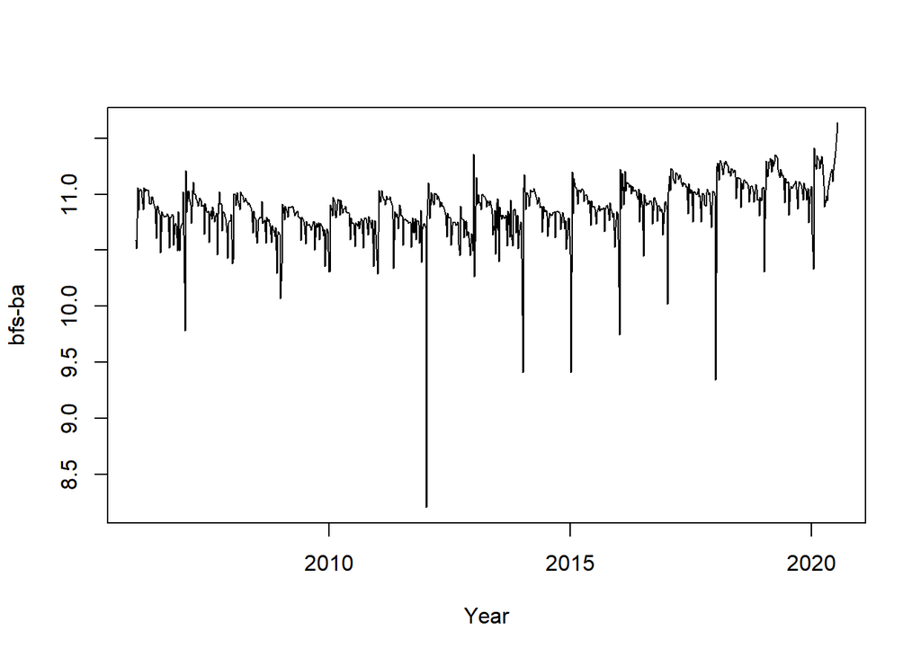

## Spectral Exploratory Analysis

- In order to get an idea about model specification, we can examine spectral estimates, using **sigex.specar**.
- We can look at raw data or differenced data (growth rates).

```r
# raw data
par(mfrow=c(1,1))
for(i in 1:length(subseries))
{
  sigex.specar(data.ts,FALSE,i,period)
}
```

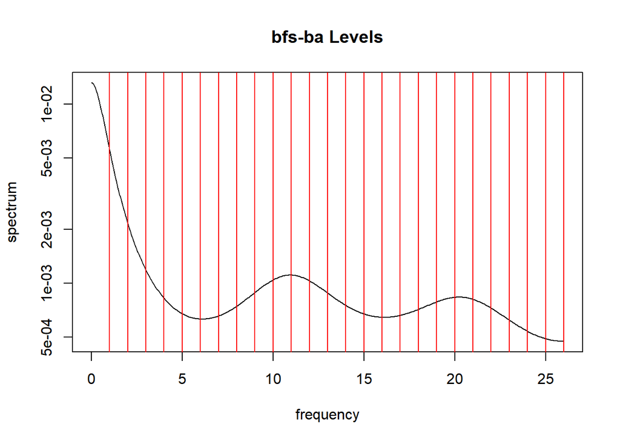

```r
dev.off()
```

```r
# growth rates
par(mfrow=c(1,1))
for(i in 1:length(subseries))
{
  sigex.specar(data.ts,TRUE,i,period)
}
dev.off()
```

[output not shown]

## Model Declaration

- Now we want to define our SARMA model.
- We begin by defining dimension $N$ and sample size $T$.

```r
N <- dim(data.ts)[2]
T <- dim(data.ts)[1]
```

- To specify the holiday regressors, we need to know the calendar date (in month-day-year format) for the beginning and end of the series, i.e., the first day of the first week and the last day of the last week.
- The function **weekly2date** provides this.
- Weekly data typically corresponds to measurements over a seven-day period beginning with Sunday, in which *first.day* is set equal to $1$.

```r
first.day <- 1
all.date <- weekly2date(first.day,begin,T)
start.date <- all.date[[1]]
end.date <- all.date[[2]]
```

- Next, we load the holiday regressors.
- One supplies an ASCI file whose every row contains a calendar date for the relevant holiday, covering a broad range of years.
- Regressors can simply be created as a daily time series by **gethol**, and then later converted to a weekly regressor.
- We use a window of $7$ days before and $0$ days after, so that the holiday effects are presumed to constitute eight days.
- In the calls to **gethol**, both *start.date* and *end.date* are required.

```r
easter.dates <- read.table(paste(root.dir,"/data/easter500.txt",sep=""))
easter.reg <- gethol(easter.dates,7,0,start.date,end.date)

nyd.dates <- read.table(paste(root.dir,"/data/newyear500.txt",sep=""))
nyd.reg <- gethol(nyd.dates,7,0,start.date,end.date)

mlk.dates <- read.table(paste(root.dir,"/data/mlk500.txt",sep=""))
mlk.reg <- gethol(mlk.dates,7,0,start.date,end.date)

gw.dates <- read.table(paste(root.dir,"/data/gw500.txt",sep=""))
gw.reg <- gethol(gw.dates,7,0,start.date,end.date)

mem.dates <- read.table(paste(root.dir,"/data/mem500.txt",sep=""))
mem.reg <- gethol(mem.dates,7,0,start.date,end.date)

ind.dates <- read.table(paste(root.dir,"/data/ind500.txt",sep=""))
ind.reg <- gethol(ind.dates,7,0,start.date,end.date)

labor.dates <- read.table(paste(root.dir,"/data/labor500.txt",sep=""))
labor.reg <- gethol(labor.dates,7,0,start.date,end.date)

col.dates <- read.table(paste(root.dir,"/data/columbus500.txt",sep=""))
col.reg <- gethol(col.dates,7,0,start.date,end.date)

vet.dates <- read.table(paste(root.dir,"/data/vet500.txt",sep=""))
vet.reg <- gethol(vet.dates,7,0,start.date,end.date)

tg.dates <- read.table(paste(root.dir,"/data/thanksgiving500.txt",sep=""))
tg.reg <- gethol(tg.dates,7,0,start.date,end.date)

xmas.dates <- read.table(paste(root.dir,"/data/xmas500.txt",sep=""))
xmas.reg <- gethol(xmas.dates,7,0,start.date,end.date)

black.dates <- read.table(paste(root.dir,"/data/black400.txt",sep=""))
black.reg <- gethol(black.dates,7,0,start.date,end.date)
```

- The daily regressors are converted to weekly flow regressors by first embedding with *sigex.daily2weekly*, followed by averaging over each week.

```r
easter.reg <- sigex.daily2weekly(easter.reg,first.day,start.date)
easter.reg <- rowSums(easter.reg)/7

nyd.reg <- sigex.daily2weekly(nyd.reg,first.day,start.date)
nyd.reg <- rowSums(nyd.reg)/7

mlk.reg <- sigex.daily2weekly(mlk.reg,first.day,start.date)
mlk.reg <- rowSums(mlk.reg)/7

gw.reg <- sigex.daily2weekly(gw.reg,first.day,start.date)
gw.reg <- rowSums(gw.reg)/7

mem.reg <- sigex.daily2weekly(mem.reg,first.day,start.date)
mem.reg <- rowSums(mem.reg)/7

ind.reg <- sigex.daily2weekly(ind.reg,first.day,start.date)
ind.reg <- rowSums(ind.reg)/7

labor.reg <- sigex.daily2weekly(labor.reg,first.day,start.date)
labor.reg <- rowSums(labor.reg)/7

col.reg <- sigex.daily2weekly(col.reg,first.day,start.date)
col.reg <- rowSums(col.reg)/7

vet.reg <- sigex.daily2weekly(vet.reg,first.day,start.date)
vet.reg <- rowSums(vet.reg)/7

tg.reg <- sigex.daily2weekly(tg.reg,first.day,start.date)
tg.reg <- rowSums(tg.reg)/7

xmas.reg <- sigex.daily2weekly(xmas.reg,first.day,start.date)
xmas.reg <- rowSums(xmas.reg)/7

black.reg <- sigex.daily2weekly(black.reg,first.day,start.date)
black.reg <- rowSums(black.reg)/7
```

## Model Construction and Fitting

### Initial Model: no holidays

- We fit a baseline model that involves no fixed effects,
- The model has a SARMA specification with order one for the AR, MA, seasonal AR, and seasonal MA polynomials.

```r
mdl <- NULL
mdl <- sigex.add(mdl,seq(1,N),"sarma",c(1,1,1,1,52),NULL,"process",1)
mdl <- sigex.meaninit(mdl,data.ts,0)
```

- Maximum Likelihood Estimation is done using BFGS. We use the divergence, which is $-2$ times the log Gaussian likelihood, with constants removed.
- With the debug option set to TRUE, the values of the divergence are printed to the console.

```r
constraint <- NULL
par.mle <- sigex.default(mdl,data.ts,constraint)
psi.mle <- sigex.par2psi(par.mle,mdl)
fit.mle <- sigex.mlefit(data.ts,par.mle,constraint,mdl,"bfgs",debug=FALSE)
psi.mle <- sigex.eta2psi(fit.mle[[1]]$par,constraint)
hess <- fit.mle[[1]]$hessian
par.mle <- fit.mle[[2]]
```

- This yields a divergence of -2076.8808399.

### Improved Model: add holidays

- The next model incorporates the the ten federal holidays along with Easter and Black Friday.
- Note that Independence Day, Veteran’s Day, and Christmas are not included by the call to *sigex.reg* (which checks for regressors that are numerically zero after differencing).

```r
mdl <- NULL
mdl <- sigex.add(mdl,seq(1,N),"sarma",c(1,1,1,1,52),NULL,"process",1)
mdl <- sigex.meaninit(mdl,data.ts,0)
mdl <- sigex.reg(mdl,1,ts(as.matrix(easter.reg),start=start(easter.reg),
                          frequency=period,names="Easter"))
mdl <- sigex.reg(mdl,1,ts(as.matrix(nyd.reg),start=start(nyd.reg),
                          frequency=period,names="NewYearDay"))
mdl <- sigex.reg(mdl,1,ts(as.matrix(mlk.reg),start=start(mlk.reg),
                          frequency=period,names="MLK"))
mdl <- sigex.reg(mdl,1,ts(as.matrix(gw.reg),start=start(gw.reg),
                          frequency=period,names="GeorgeWashington"))
mdl <- sigex.reg(mdl,1,ts(as.matrix(mem.reg),start=start(mem.reg),
                          frequency=period,names="MemorialDay"))
mdl <- sigex.reg(mdl,1,ts(as.matrix(ind.reg),start=start(ind.reg),
                          frequency=period,names="IndependenceDay"))
mdl <- sigex.reg(mdl,1,ts(as.matrix(labor.reg),start=start(labor.reg),
                          frequency=period,names="LaborDay"))
mdl <- sigex.reg(mdl,1,ts(as.matrix(col.reg),start=start(col.reg),
                          frequency=period,names="ColumbusDay"))
mdl <- sigex.reg(mdl,1,ts(as.matrix(vet.reg),start=start(vet.reg),
                          frequency=period,names="VeteransDay"))
mdl <- sigex.reg(mdl,1,ts(as.matrix(tg.reg),start=start(tg.reg),
                          frequency=period,names="Thanksgiving"))
mdl <- sigex.reg(mdl,1,ts(as.matrix(xmas.reg),start=start(xmas.reg),
                          frequency=period,names="Xmas"))
mdl <- sigex.reg(mdl,1,ts(as.matrix(black.reg),start=start(black.reg),
                          frequency=period,names="BlackFriday"))
```

- This specification has seven federal holidays, plus two other holidays and the trend constant, for a total of $10$ regressors.
- The model is fitted next.

```r
constraint <- NULL
par.mle <- sigex.default(mdl,data.ts,constraint)
psi.mle <- sigex.par2psi(par.mle,mdl)
fit.mle <- sigex.mlefit(data.ts,par.mle,constraint,mdl,"bfgs",debug=FALSE)
psi.mle <- sigex.eta2psi(fit.mle[[1]]$par,constraint)
hess <- fit.mle[[1]]$hessian
par.mle <- fit.mle[[2]]
```

- This yields a divergence of -2088.0603012.
- We can also examine the Hessian matrix, and compute the t statistics for pre-parameters.

```r
print(eigen(hess)$values)
```

```
##  [1] 1267.28228888  765.87829539  397.03988257  358.61010402  239.26250704
##  [6]  213.32591113  208.58523439  193.02495813  175.55632465  169.37310390
## [11]   24.66449409   13.36019657    9.98192072    0.15646313   -0.01327668
```

- We obtain, format, and store the residuals.
- Then we compute the autocorrelations, and plot.

```r
resid.mle <- sigex.resid(psi.mle,mdl,data.ts)[[1]]
resid.mle <- sigex.load(t(resid.mle),start(data.ts),frequency(data.ts),colnames(data.ts),TRUE)
```

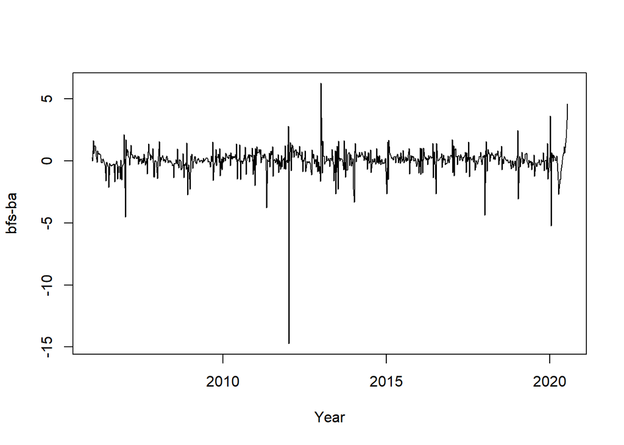

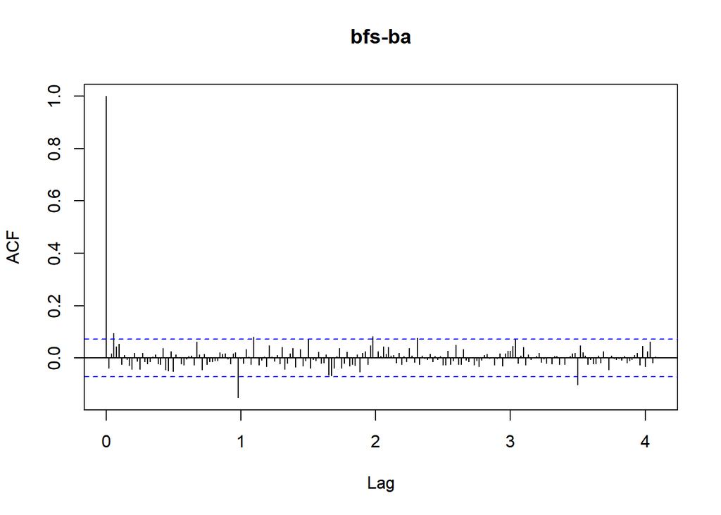

```r
resid.acf <- acf(resid.mle,lag.max=4*53,plot=TRUE)$acf
```

- We observe in the fitted residuals that there is a substantial outlier in the first week of 2012, which is not explained by the New Year’s regressor.
- In a refined model below, this will be handled as an Additive Outlier.

### Final Model

```r
AO.times <- 314
dataNA.ts <- data.ts
dataNA.ts[AO.times] <- NA
```

- Next, we construct the model.

```r
mdl <- NULL
mdl <- sigex.add(mdl,seq(1,N),"sarma",c(1,1,1,1,52),NULL,"process",1)
mdl <- sigex.meaninit(mdl,dataNA.ts,0)
mdl <- sigex.reg(mdl,1,ts(as.matrix(nyd.reg),start=start(nyd.reg),
                          frequency=period,names="NewYearDay"))
mdl <- sigex.reg(mdl,1,ts(as.matrix(mlk.reg),start=start(mlk.reg),
                          frequency=period,names="MLK"))
```

- The model is fitted next.

```r
constraint <- NULL
par.mle <- sigex.default(mdl,dataNA.ts,constraint)
psi.mle <- sigex.par2psi(par.mle,mdl)
fit.mle <- sigex.mlefit(dataNA.ts,par.mle,constraint,mdl,"bfgs",debug=FALSE)
psi.mle <- sigex.eta2psi(fit.mle[[1]]$par,constraint)
hess <- fit.mle[[1]]$hessian
par.mle <- fit.mle[[2]]
```

- This yields a divergence of -2013.3180214.
- We can examine t statistics for the parameters.

```r
sigex.tstats(mdl,psi.mle,hess,constraint)
```

```
## [1] -79.240599   6.232937   7.086758   9.702912   5.397648  64.783281  -4.908657
## [8]  -2.773630
```

- We obtain, format, and store the residuals.
- Then we compute the autocorrelations, and plot.

```r
resid.mle <- sigex.resid(psi.mle,mdl,dataNA.ts)[[1]]
resid.mle <- sigex.load(t(resid.mle),start(data.ts),
                        frequency(data.ts),colnames(data.ts),TRUE)
```

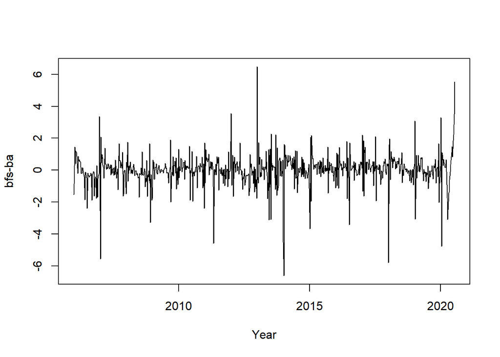

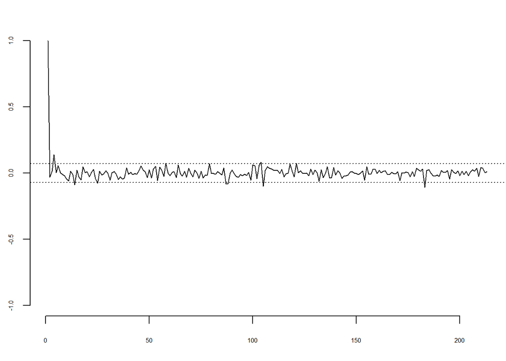

```r
resid.acf <- acf(resid.mle,lag.max=4*53,plot=FALSE)$acf
par(mfrow=c(N,N),mar=c(3,2,2,0)+0.1,cex.lab=.8,cex.axis=.5,bty="n")
for(j in 1:N)
{
  for(k in 1:N)
  {
    plot.ts(resid.acf[,j,k],ylab="",xlab="Lag",ylim=c(-1,1),cex=.5)
    abline(h=1.96/sqrt(T),lty=3)
    abline(h=-1.96/sqrt(T),lty=3)
  }
}
```

```r
dev.off()
```

```r
sigex.portmanteau(resid.mle,4*period,length(psi.mle))
```

```
## [1] 177.0359421   0.8773168
```

```r
sigex.gausscheck(resid.mle)
```

```
## [1] 2.23972e-27
```

- We obtain the midcast (imputation for a missing value) for time $t=314$.

```r
data.casts <- sigex.midcast(psi.mle,mdl,dataNA.ts,0)
```

- Having completed our model analysis, we store our results in a single list object.

```r
analysis.mle <- sigex.bundle(dataNA.ts,transform,mdl,psi.mle)
```

## Signal Extraction

- The final stage of analysis is to filter the data.
- First we load up the bundled data.

```r
dataNA.ts <- analysis.mle[[1]]
mdl <- analysis.mle[[3]]
psi <- analysis.mle[[4]]
param <- sigex.psi2par(psi,mdl,dataNA.ts)
```

- The relevant fixed effects are loaded into variables.
- To do this we create a variable *dataLIN.ts*, consisting of the orginal time series with the fixed effects removed.
- This de-meaned series shall be adjusted for the AO, and then filtered.

```r
reg.trend <- sigex.fixed(data.ts,mdl,1,param,"Trend")
reg.nyd <- sigex.fixed(data.ts,mdl,1,param,"NewYearDay")
reg.mlk <- sigex.fixed(data.ts,mdl,1,param,"MLK")
dataLIN.ts <- data.ts - ts(reg.trend + reg.nyd + reg.mlk,
                           start=start(data.ts),frequency=period)
```

- We utilize a set of nonparametric filters to extract trend, seasonal, and non-seasonal (or seasonally adjusted) latent processes, implemented in **x11filters**.
- Below, we define *week.period* with a non-integer period, which **x11filters** is designed to accomodate.
- The variable *x11.filters* is a three-item list containing the three filters, each of which is a symmetric sequence of numbers.

```r
week.period <- 365.25/7
half.len <- floor(week.period/2)
x11.filters <- x11filters(week.period,1)
trend.filter <- x11.filters[[1]]
seas.filter <- x11.filters[[2]]
sa.filter <- x11.filters[[3]]
shift <- (dim(sa.filter)[3]-1)/2
```

```r
trend.comp <- sigex.adhocextract(psi,mdl,dataNA.ts,trend.filter,half.len,0,TRUE)
sa.comp <- sigex.adhocextract(psi,mdl,dataNA.ts,sa.filter,shift,0,TRUE)
AO.errs <- dataLIN.ts[AO.times] - data.casts[[1]]
sa.comp[[1]][AO.times] <- sa.comp[[1]][AO.times] + AO.errs
```

- The results can be displayed using calls to **sigex.graph**.
- This code sets up various colors for the extractions, and a shading percentage *fade*.

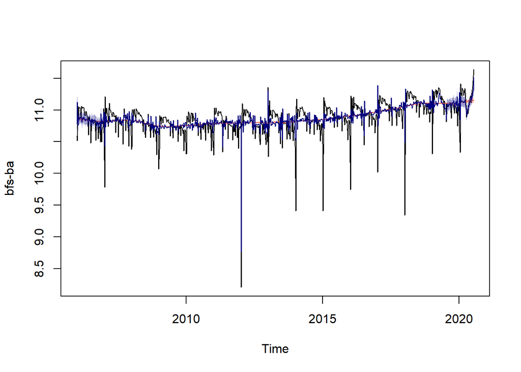

```r
trendcol <- "tomato"
cyccol <- "orchid"
seascol <- "seagreen"
sacol <- "navyblue"
fade <- 60

plot(data.ts)
sigex.graph(trend.comp,reg.trend,start(data.ts),
            period,1,0,trendcol,fade)
sigex.graph(sa.comp,reg.trend,start(data.ts),
            period,1,0,sacol,fade)
```

```r
dev.off()
```

- Next, we can examine spectral density estimates of the extractions.

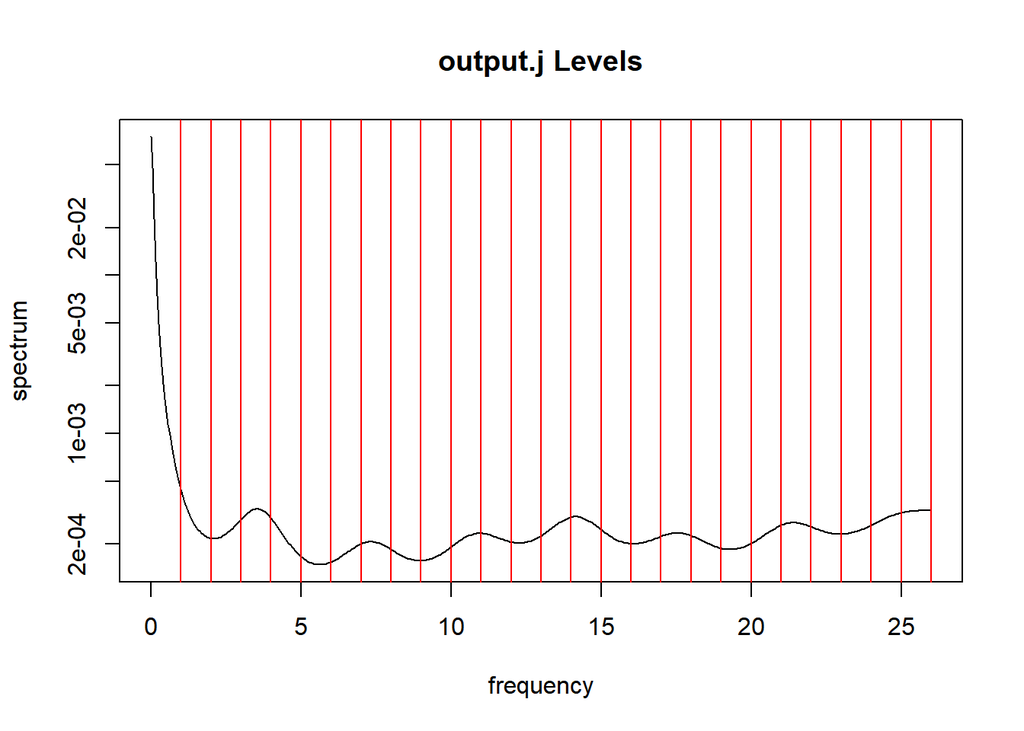

```r
sigex.specar(sa.comp[[1]],FALSE,1,period)
```

```r
dev.off()
```

- The lack of seasonal peaks indicates adequacy of the seasonal adjustment.